# Predictive Modeling Final Project

Sai

2024-04-28

## Direct-Mail Fundraising- Predictive Modeling Final Project:-

## Background:-

A national veterans’ organization wishes to develop a predictive model to improve the cost-effectiveness of their direct marketing campaign. The organization, with its in-house database of over 13 million donors, is one of the largest direct-mail fundraisers in the United States. According to their recent mailing records, the overall response rate is 5.1%. Out of those who responded (donated), the average donation is $13.00. Each mailing, which includes a gift of personalized address labels and assortments of cards and envelopes, costs $0.68 to produce and send.

## Business Problem:-

Using these facts, we take a sample of this dataset to develop a classification model that can effectively capture donors so that the expected net profit is maximized. Weighted sampling was used, under-representing the non-responders so that the sample has equal numbers of donors and non-donors.

## required libraries:-

```r
library(ggplot2)
library(dplyr)
library(corrplot)
library(randomForest)
library(e1071)
library(class)
library(caret)
library(moments)
library(skimr)
library(ggplot2)
library(reshape2)
library(gridExtra)
library(car)
library(caret)
library(ROCR)
library(ISLR)
library(GGally)
```

## Setting the seed:-

```r
set.seed(12345)
```

## Loading the Fundraising_data:-

```r
Fundraising_data <- read.csv("D:\\UTSA\\Spring 2024\\Predictive Modeling\\Project\\fundraising.csv")

Future_fundraising<-read.csv("D:\\UTSA\\Spring 2024\\Predictive Modeling\\Project\\Test\\future_fundraising.csv")
```

## Checking for NA and count of NA:-

```r
# Checking for NA values and count them - Fundraising_data
na_count_fundraising <- sum(is.na(Fundraising_data))
cat("Number of missing values in Fundraising_data:", na_count_fundraising, "\n")
```

```
## Number of missing values in Fundraising_data: 0
```

```r
# Checking for NA values and count them - Future_fundraising
na_count_future <- sum(is.na(Future_fundraising))
cat("Number of missing values in Future_fundraising:", na_count_future, "\n")
```

```
## Number of missing values in Future_fundraising: 0
```

## Summary- Fundraising_data:-

```r
summary(Fundraising_data)
```

```
##  zipconvert2        zipconvert3        zipconvert4        zipconvert5
##  Length:3000        Length:3000        Length:3000        Length:3000
##  Class :character   Class :character   Class :character   Class :character
##  Mode  :character   Mode  :character   Mode  :character   Mode  :character
##
##
##
##   homeowner           num_child         income         female
##  Length:3000        Min.   :1.000   Min.   :1.000   Length:3000
##  Class :character   1st Qu.:1.000   1st Qu.:3.000   Class :character
##  Mode  :character   Median :1.000   Median :4.000   Mode  :character
##                     Mean   :1.069   Mean   :3.899
##                     3rd Qu.:1.000   3rd Qu.:5.000
##                     Max.   :5.000   Max.   :7.000
##      wealth        home_value      med_fam_inc      avg_fam_inc
##  Min.   :0.000   Min.   :   0.0   Min.   :   0.0   Min.   :   0.0
##  1st Qu.:5.000   1st Qu.: 554.8   1st Qu.: 278.0   1st Qu.: 318.0
##  Median :8.000   Median : 816.5   Median : 355.0   Median : 396.0
##  Mean   :6.396   Mean   :1143.3   Mean   : 388.4   Mean   : 432.3
##  3rd Qu.:8.000   3rd Qu.:1341.2   3rd Qu.: 465.0   3rd Qu.: 516.0
##  Max.   :9.000   Max.   :5945.0   Max.   :1500.0   Max.   :1331.0
##    pct_lt15k        num_prom      lifetime_gifts    largest_gift
##  Min.   : 0.00   Min.   : 11.00   Min.   :  15.0   Min.   :   5.00
##  1st Qu.: 5.00   1st Qu.: 29.00   1st Qu.:  45.0   1st Qu.:  10.00
##  Median :12.00   Median : 48.00   Median :  81.0   Median :  15.00
##  Mean   :14.71   Mean   : 49.14   Mean   : 110.7   Mean   :  16.65
##  3rd Qu.:21.00   3rd Qu.: 65.00   3rd Qu.: 135.0   3rd Qu.:  20.00
##  Max.   :90.00   Max.   :157.00   Max.   :5674.9   Max.   :1000.00
##    last_gift      months_since_donate    time_lag         avg_gift
##  Min.   :  0.00   Min.   :17.00       Min.   : 0.000   Min.   :  2.139
##  1st Qu.:  7.00   1st Qu.:29.00       1st Qu.: 3.000   1st Qu.:  6.333
##  Median : 10.00   Median :31.00       Median : 5.000   Median :  9.000
##  Mean   : 13.48   Mean   :31.13       Mean   : 6.876   Mean   : 10.669
##  3rd Qu.: 16.00   3rd Qu.:34.00       3rd Qu.: 9.000   3rd Qu.: 12.800
##  Max.   :219.00   Max.   :37.00       Max.   :77.000   Max.   :122.167
##     target
##  Length:3000
##  Class :character
##  Mode  :character
##
##
##
```

## Summary- Future_fundraising:-

```r
summary(Future_fundraising)
```

```
##  zipconvert2        zipconvert3        zipconvert4        zipconvert5
##  Length:120         Length:120         Length:120         Length:120
##  Class :character   Class :character   Class :character   Class :character
##  Mode  :character   Mode  :character   Mode  :character   Mode  :character
##
##
##
##   homeowner           num_child         income         female
##  Length:120         Min.   :1.000   Min.   :1.000   Length:120
##  Class :character   1st Qu.:1.000   1st Qu.:2.750   Class :character
##  Mode  :character   Median :1.000   Median :4.000   Mode  :character
##                     Mean   :1.067   Mean   :3.767
##                     3rd Qu.:1.000   3rd Qu.:5.000
##                     Max.   :4.000   Max.   :7.000
##      wealth        home_value      med_fam_inc     avg_fam_inc
##  Min.   :0.000   Min.   :   0.0   Min.   :  0.0   Min.   :  0.0
##  1st Qu.:5.750   1st Qu.: 579.5   1st Qu.:276.2   1st Qu.:311.8
##  Median :8.000   Median : 897.5   Median :359.0   Median :405.5
##  Mean   :6.567   Mean   :1093.7   Mean   :384.7   Mean   :426.5
##  3rd Qu.:8.000   3rd Qu.:1319.5   3rd Qu.:474.8   3rd Qu.:522.2
##  Max.   :9.000   Max.   :5413.0   Max.   :823.0   Max.   :813.0
##    pct_lt15k        num_prom      lifetime_gifts   largest_gift
##  Min.   : 0.00   Min.   : 15.00   Min.   : 15.0   Min.   :  5.00
##  1st Qu.: 5.00   1st Qu.: 29.75   1st Qu.: 45.0   1st Qu.: 10.00
##  Median :12.50   Median : 47.00   Median : 82.0   Median : 15.00
##  Mean   :14.52   Mean   : 47.85   Mean   :101.9   Mean   : 16.79
##  3rd Qu.:21.25   3rd Qu.: 64.00   3rd Qu.:126.5   3rd Qu.: 20.00
##  Max.   :63.00   Max.   :103.00   Max.   :431.0   Max.   :100.00
##    last_gift      months_since_donate    time_lag         avg_gift
##  Min.   :  1.00   Min.   :17.00       Min.   : 0.000   Min.   : 2.963
##  1st Qu.:  7.00   1st Qu.:29.00       1st Qu.: 3.750   1st Qu.: 6.819
##  Median : 12.00   Median :31.00       Median : 5.000   Median : 9.331
##  Mean   : 14.52   Mean   :31.24       Mean   : 6.508   Mean   :11.235
##  3rd Qu.: 16.00   3rd Qu.:35.00       3rd Qu.: 9.000   3rd Qu.:13.354
##  Max.   :100.00   Max.   :37.00       Max.   :26.000   Max.   :42.500
```

## View - Fundraising_data:-

```r
head(Fundraising_data)
```

```
##   zipconvert2 zipconvert3 zipconvert4 zipconvert5 homeowner num_child income
## 1         Yes          No          No          No       Yes         1      1
## 2          No          No          No         Yes        No         2      5
## 3          No          No          No         Yes       Yes         1      3
## 4          No         Yes          No          No       Yes         1      4
## 5          No         Yes          No          No       Yes         1      4
## 6          No          No          No         Yes       Yes         1      4
##   female wealth home_value med_fam_inc avg_fam_inc pct_lt15k num_prom
## 1     No      7        698         422         463         4       46
## 2    Yes      8        828         358         376        13       32
## 3     No      4       1471         484         546         4       94
## 4     No      8        547         386         432         7       20
## 5    Yes      8        482         242         275        28       38
## 6    Yes      8        857         450         498         5       47
##   lifetime_gifts largest_gift last_gift months_since_donate time_lag  avg_gift
## 1             94           12        12                  34        6  9.400000
## 2             30           10         5                  29        7  4.285714
## 3            177           10         8                  30        3  7.080000
## 4             23           11        11                  30        6  7.666667
## 5             73           10        10                  31        3  7.300000
## 6            139           20        20                  37        3 10.692308
##     target
## 1    Donor
## 2    Donor
## 3 No Donor
## 4 No Donor
## 5    Donor
## 6    Donor
```

## View - Future_fundraising:-

```r
head(Future_fundraising)
```

```
##   zipconvert2 zipconvert3 zipconvert4 zipconvert5 homeowner num_child income
## 1          No         Yes          No          No       Yes         1      5
## 2         Yes          No          No          No       Yes         1      1
## 3          No          No          No         Yes       Yes         1      4
## 4          No          No         Yes          No       Yes         1      4
## 5          No         Yes          No          No       Yes         1      2
## 6         Yes          No          No          No       Yes         1      4
##   female wealth home_value med_fam_inc avg_fam_inc pct_lt15k num_prom
## 1    Yes      9       1399         637         703         1       74
## 2     No      7       1355         411         497         9       77
## 3    Yes      1        835         310         364        22       70
## 4     No      8       1019         389         473        15       21
## 5    Yes      7        992         524         563         6       63
## 6    Yes      8        834         371         408        10       35
##   lifetime_gifts largest_gift last_gift months_since_donate time_lag  avg_gift
## 1            102            6         5                  29        3  4.857143
## 2            249           15         7                  35        3  9.576923
## 3            126            6         6                  34        8  4.344828
## 4             26           16        16                  37        5 13.000000
## 5            100           20         3                  21        6  7.692308
## 6             92           37        37                  37        5 23.000000
```

## Structure of the Fundraising_data:-

```r
str(Fundraising_data)
```

```
## 'data.frame':    3000 obs. of  21 variables:
##  $ zipconvert2        : chr  "Yes" "No" "No" "No" ...
##  $ zipconvert3        : chr  "No" "No" "No" "Yes" ...
##  $ zipconvert4        : chr  "No" "No" "No" "No" ...
##  $ zipconvert5        : chr  "No" "Yes" "Yes" "No" ...
##  $ homeowner          : chr  "Yes" "No" "Yes" "Yes" ...
##  $ num_child          : int  1 2 1 1 1 1 1 1 1 1 ...
##  $ income             : int  1 5 3 4 4 4 4 4 4 1 ...
##  $ female             : chr  "No" "Yes" "No" "No" ...
##  $ wealth             : int  7 8 4 8 8 8 5 8 8 5 ...
##  $ home_value         : int  698 828 1471 547 482 857 505 1438 1316 428 ...
##  $ med_fam_inc        : int  422 358 484 386 242 450 333 458 541 203 ...
##  $ avg_fam_inc        : int  463 376 546 432 275 498 388 533 575 271 ...
##  $ pct_lt15k          : int  4 13 4 7 28 5 16 8 11 39 ...
##  $ num_prom           : int  46 32 94 20 38 47 51 21 66 73 ...
##  $ lifetime_gifts     : num  94 30 177 23 73 139 63 26 108 161 ...
##  $ largest_gift       : num  12 10 10 11 10 20 15 16 12 6 ...
##  $ last_gift          : num  12 5 8 11 10 20 10 16 7 3 ...
##  $ months_since_donate: int  34 29 30 30 31 37 37 30 31 32 ...
##  $ time_lag           : int  6 7 3 6 3 3 8 6 1 7 ...
##  $ avg_gift           : num  9.4 4.29 7.08 7.67 7.3 ...
##  $ target             : chr  "Donor" "Donor" "No Donor" "No Donor" ...
```

## Structure of the Future_fundraising:-

```r
str(Future_fundraising)
```

```
## 'data.frame':    120 obs. of  20 variables:
##  $ zipconvert2        : chr  "No" "Yes" "No" "No" ...
##  $ zipconvert3        : chr  "Yes" "No" "No" "No" ...
##  $ zipconvert4        : chr  "No" "No" "No" "Yes" ...
##  $ zipconvert5        : chr  "No" "No" "Yes" "No" ...
##  $ homeowner          : chr  "Yes" "Yes" "Yes" "Yes" ...
##  $ num_child          : int  1 1 1 1 1 1 1 1 1 1 ...
##  $ income             : int  5 1 4 4 2 4 2 3 4 2 ...
##  $ female             : chr  "Yes" "No" "Yes" "No" ...
##  $ wealth             : int  9 7 1 8 7 8 1 8 3 5 ...
##  $ home_value         : int  1399 1355 835 1019 992 834 639 457 349 698 ...
##  $ med_fam_inc        : int  637 411 310 389 524 371 209 253 302 335 ...
##  $ avg_fam_inc        : int  703 497 364 473 563 408 259 285 324 348 ...
##  $ pct_lt15k          : int  1 9 22 15 6 10 36 25 19 14 ...
##  $ num_prom           : int  74 77 70 21 63 35 72 68 55 59 ...
##  $ lifetime_gifts     : num  102 249 126 26 100 92 146 98 66 276 ...
##  $ largest_gift       : num  6 15 6 16 20 37 12 5 7 15 ...
##  $ last_gift          : num  5 7 6 16 3 37 11 3 5 13 ...
##  $ months_since_donate: int  29 35 34 37 21 37 36 32 30 33 ...
##  $ time_lag           : int  3 3 8 5 6 5 5 9 9 10 ...
##  $ avg_gift           : num  4.86 9.58 4.34 13 7.69 ...
```

## Converting the Char to as.factor for Fundraising_data:

```r
char_vars <- sapply(Fundraising_data, is.character)

Fundraising_data[char_vars] <- lapply(Fundraising_data[char_vars], as.factor)
str(Fundraising_data)
```

```
## 'data.frame':    3000 obs. of  21 variables:
##  $ zipconvert2        : Factor w/ 2 levels "No","Yes": 2 1 1 1 1 1 1 2 1 2 ...
##  $ zipconvert3        : Factor w/ 2 levels "No","Yes": 1 1 1 2 2 1 1 1 1 1 ...
##  $ zipconvert4        : Factor w/ 2 levels "No","Yes": 1 1 1 1 1 1 2 1 1 1 ...
##  $ zipconvert5        : Factor w/ 2 levels "No","Yes": 1 2 2 1 1 2 1 1 2 1 ...
##  $ homeowner          : Factor w/ 2 levels "No","Yes": 2 1 2 2 2 2 2 2 2 2 ...
##  $ num_child          : int  1 2 1 1 1 1 1 1 1 1 ...
##  $ income             : int  1 5 3 4 4 4 4 4 4 1 ...
##  $ female             : Factor w/ 2 levels "No","Yes": 1 2 1 1 2 2 1 2 2 2 ...
##  $ wealth             : int  7 8 4 8 8 8 5 8 8 5 ...
##  $ home_value         : int  698 828 1471 547 482 857 505 1438 1316 428 ...
##  $ med_fam_inc        : int  422 358 484 386 242 450 333 458 541 203 ...
##  $ avg_fam_inc        : int  463 376 546 432 275 498 388 533 575 271 ...
##  $ pct_lt15k          : int  4 13 4 7 28 5 16 8 11 39 ...
##  $ num_prom           : int  46 32 94 20 38 47 51 21 66 73 ...
##  $ lifetime_gifts     : num  94 30 177 23 73 139 63 26 108 161 ...
##  $ largest_gift       : num  12 10 10 11 10 20 15 16 12 6 ...
##  $ last_gift          : num  12 5 8 11 10 20 10 16 7 3 ...
##  $ months_since_donate: int  34 29 30 30 31 37 37 30 31 32 ...
##  $ time_lag           : int  6 7 3 6 3 3 8 6 1 7 ...
##  $ avg_gift           : num  9.4 4.29 7.08 7.67 7.3 ...
##  $ target             : Factor w/ 2 levels "Donor","No Donor": 1 1 2 2 1 1 1 2 1 1 ...
```

## Converting the Char to as.factor for Future_fundraising:

```r
char_vars <- sapply(Future_fundraising, is.character)


Future_fundraising[char_vars] <- lapply(Future_fundraising[char_vars], as.factor)
str(Future_fundraising)
```

```
## 'data.frame':    120 obs. of  20 variables:
##  $ zipconvert2        : Factor w/ 2 levels "No","Yes": 1 2 1 1 1 2 1 2 1 1 ...
##  $ zipconvert3        : Factor w/ 2 levels "No","Yes": 2 1 1 1 2 1 2 1 2 2 ...
##  $ zipconvert4        : Factor w/ 2 levels "No","Yes": 1 1 1 2 1 1 1 1 1 1 ...
##  $ zipconvert5        : Factor w/ 2 levels "No","Yes": 1 1 2 1 1 1 1 1 1 1 ...
##  $ homeowner          : Factor w/ 2 levels "No","Yes": 2 2 2 2 2 2 2 2 1 1 ...
##  $ num_child          : int  1 1 1 1 1 1 1 1 1 1 ...
##  $ income             : int  5 1 4 4 2 4 2 3 4 2 ...
##  $ female             : Factor w/ 2 levels "No","Yes": 2 1 2 1 2 2 2 1 1 1 ...
##  $ wealth             : int  9 7 1 8 7 8 1 8 3 5 ...
##  $ home_value         : int  1399 1355 835 1019 992 834 639 457 349 698 ...
##  $ med_fam_inc        : int  637 411 310 389 524 371 209 253 302 335 ...
##  $ avg_fam_inc        : int  703 497 364 473 563 408 259 285 324 348 ...
##  $ pct_lt15k          : int  1 9 22 15 6 10 36 25 19 14 ...
##  $ num_prom           : int  74 77 70 21 63 35 72 68 55 59 ...
##  $ lifetime_gifts     : num  102 249 126 26 100 92 146 98 66 276 ...
##  $ largest_gift       : num  6 15 6 16 20 37 12 5 7 15 ...
##  $ last_gift          : num  5 7 6 16 3 37 11 3 5 13 ...
##  $ months_since_donate: int  29 35 34 37 21 37 36 32 30 33 ...
##  $ time_lag           : int  3 3 8 5 6 5 5 9 9 10 ...
##  $ avg_gift           : num  4.86 9.58 4.34 13 7.69 ...
```

## Summary- Fundraising_data post converting to as.factor:-

```r
summary(Fundraising_data)
```

```
##  zipconvert2 zipconvert3 zipconvert4 zipconvert5 homeowner    num_child
##  No :2352    No :2449    No :2357    No :1846    No : 688   Min.   :1.000
##  Yes: 648    Yes: 551    Yes: 643    Yes:1154    Yes:2312   1st Qu.:1.000
##                                                             Median :1.000
##                                                             Mean   :1.069
##                                                             3rd Qu.:1.000
##                                                             Max.   :5.000
##      income      female         wealth        home_value      med_fam_inc
##  Min.   :1.000   No :1169   Min.   :0.000   Min.   :   0.0   Min.   :   0.0
##  1st Qu.:3.000   Yes:1831   1st Qu.:5.000   1st Qu.: 554.8   1st Qu.: 278.0
##  Median :4.000              Median :8.000   Median : 816.5   Median : 355.0
##  Mean   :3.899              Mean   :6.396   Mean   :1143.3   Mean   : 388.4
##  3rd Qu.:5.000              3rd Qu.:8.000   3rd Qu.:1341.2   3rd Qu.: 465.0
##  Max.   :7.000              Max.   :9.000   Max.   :5945.0   Max.   :1500.0
##   avg_fam_inc       pct_lt15k        num_prom      lifetime_gifts
##  Min.   :   0.0   Min.   : 0.00   Min.   : 11.00   Min.   :  15.0
##  1st Qu.: 318.0   1st Qu.: 5.00   1st Qu.: 29.00   1st Qu.:  45.0
##  Median : 396.0   Median :12.00   Median : 48.00   Median :  81.0
##  Mean   : 432.3   Mean   :14.71   Mean   : 49.14   Mean   : 110.7
##  3rd Qu.: 516.0   3rd Qu.:21.00   3rd Qu.: 65.00   3rd Qu.: 135.0
##  Max.   :1331.0   Max.   :90.00   Max.   :157.00   Max.   :5674.9
##   largest_gift       last_gift      months_since_donate    time_lag
##  Min.   :   5.00   Min.   :  0.00   Min.   :17.00       Min.   : 0.000
##  1st Qu.:  10.00   1st Qu.:  7.00   1st Qu.:29.00       1st Qu.: 3.000
##  Median :  15.00   Median : 10.00   Median :31.00       Median : 5.000
##  Mean   :  16.65   Mean   : 13.48   Mean   :31.13       Mean   : 6.876
##  3rd Qu.:  20.00   3rd Qu.: 16.00   3rd Qu.:34.00       3rd Qu.: 9.000
##  Max.   :1000.00   Max.   :219.00   Max.   :37.00       Max.   :77.000
##     avg_gift            target
##  Min.   :  2.139   Donor   :1499
##  1st Qu.:  6.333   No Donor:1501
##  Median :  9.000
##  Mean   : 10.669
##  3rd Qu.: 12.800
##  Max.   :122.167
```

## Another way to summarize the data:

```r
skim(Fundraising_data)
```

Data summary

| Name | Fundraising_data |
| --- | --- |
| Number of rows | 3000 |
| Number of columns | 21 |
| _______________________ |  |
| Column type frequency: |  |
| factor | 7 |
| numeric | 14 |
| ________________________ |  |
| Group variables | None |

**Variable type: factor**

| skim_variable | n_missing | complete_rate | ordered | n_unique | top_counts |
| --- | --- | --- | --- | --- | --- |
| zipconvert2 | 0 | 1 | FALSE | 2 | No: 2352, Yes: 648 |
| zipconvert3 | 0 | 1 | FALSE | 2 | No: 2449, Yes: 551 |
| zipconvert4 | 0 | 1 | FALSE | 2 | No: 2357, Yes: 643 |
| zipconvert5 | 0 | 1 | FALSE | 2 | No: 1846, Yes: 1154 |
| homeowner | 0 | 1 | FALSE | 2 | Yes: 2312, No: 688 |
| female | 0 | 1 | FALSE | 2 | Yes: 1831, No: 1169 |
| target | 0 | 1 | FALSE | 2 | No : 1501, Don: 1499 |

**Variable type: numeric**

| skim_variable | n_missing | complete_rate | mean | sd | p0 | p25 | p50 | p75 | p100 | hist |
| --- | --- | --- | --- | --- | --- | --- | --- | --- | --- | --- |
| num_child | 0 | 1 | 1.07 | 0.35 | 1.00 | 1.00 | 1.0 | 1.00 | 5.00 | ▇▁▁▁▁ |
| income | 0 | 1 | 3.90 | 1.64 | 1.00 | 3.00 | 4.0 | 5.00 | 7.00 | ▆▂▇▅▃ |
| wealth | 0 | 1 | 6.40 | 2.55 | 0.00 | 5.00 | 8.0 | 8.00 | 9.00 | ▁▁▂▂▇ |
| home_value | 0 | 1 | 1143.27 | 952.15 | 0.00 | 554.75 | 816.5 | 1341.25 | 5945.00 | ▇▂▁▁▁ |
| med_fam_inc | 0 | 1 | 388.36 | 173.73 | 0.00 | 278.00 | 355.0 | 465.00 | 1500.00 | ▅▇▁▁▁ |
| avg_fam_inc | 0 | 1 | 432.31 | 168.90 | 0.00 | 318.00 | 396.0 | 516.00 | 1331.00 | ▁▇▂▁▁ |
| pct_lt15k | 0 | 1 | 14.71 | 12.11 | 0.00 | 5.00 | 12.0 | 21.00 | 90.00 | ▇▃▁▁▁ |
| num_prom | 0 | 1 | 49.14 | 22.78 | 11.00 | 29.00 | 48.0 | 65.00 | 157.00 | ▇▇▃▁▁ |
| lifetime_gifts | 0 | 1 | 110.74 | 149.38 | 15.00 | 45.00 | 81.0 | 135.00 | 5674.90 | ▇▁▁▁▁ |
| largest_gift | 0 | 1 | 16.65 | 22.52 | 5.00 | 10.00 | 15.0 | 20.00 | 1000.00 | ▇▁▁▁▁ |
| last_gift | 0 | 1 | 13.48 | 10.48 | 0.00 | 7.00 | 10.0 | 16.00 | 219.00 | ▇▁▁▁▁ |
| months_since_donate | 0 | 1 | 31.13 | 4.10 | 17.00 | 29.00 | 31.0 | 34.00 | 37.00 | ▁▁▅▇▅ |
| time_lag | 0 | 1 | 6.88 | 5.60 | 0.00 | 3.00 | 5.0 | 9.00 | 77.00 | ▇▁▁▁▁ |
| avg_gift | 0 | 1 | 10.67 | 7.45 | 2.14 | 6.33 | 9.0 | 12.80 | 122.17 | ▇▁▁▁▁ |

## Interpretation:

We can use this summary of the data, to understand the descriptive statistics, data skewness through histogram and number of numeric and factor conversion data type variables, missing data by variable wise.

## Summary- Future_fundraising post converting to as.factor:-

```r
summary(Future_fundraising)
```

```
##  zipconvert2 zipconvert3 zipconvert4 zipconvert5 homeowner   num_child
##  No :99      No :93      No :94      No :74      No :29    Min.   :1.000
##  Yes:21      Yes:27      Yes:26      Yes:46      Yes:91    1st Qu.:1.000
##                                                            Median :1.000
##                                                            Mean   :1.067
##                                                            3rd Qu.:1.000
##                                                            Max.   :4.000
##      income      female       wealth        home_value      med_fam_inc
##  Min.   :1.000   No :50   Min.   :0.000   Min.   :   0.0   Min.   :  0.0
##  1st Qu.:2.750   Yes:70   1st Qu.:5.750   1st Qu.: 579.5   1st Qu.:276.2
##  Median :4.000            Median :8.000   Median : 897.5   Median :359.0
##  Mean   :3.767            Mean   :6.567   Mean   :1093.7   Mean   :384.7
##  3rd Qu.:5.000            3rd Qu.:8.000   3rd Qu.:1319.5   3rd Qu.:474.8
##  Max.   :7.000            Max.   :9.000   Max.   :5413.0   Max.   :823.0
##   avg_fam_inc      pct_lt15k        num_prom      lifetime_gifts
##  Min.   :  0.0   Min.   : 0.00   Min.   : 15.00   Min.   : 15.0
##  1st Qu.:311.8   1st Qu.: 5.00   1st Qu.: 29.75   1st Qu.: 45.0
##  Median :405.5   Median :12.50   Median : 47.00   Median : 82.0
##  Mean   :426.5   Mean   :14.52   Mean   : 47.85   Mean   :101.9
##  3rd Qu.:522.2   3rd Qu.:21.25   3rd Qu.: 64.00   3rd Qu.:126.5
##  Max.   :813.0   Max.   :63.00   Max.   :103.00   Max.   :431.0
##   largest_gift      last_gift      months_since_donate    time_lag
##  Min.   :  5.00   Min.   :  1.00   Min.   :17.00       Min.   : 0.000
##  1st Qu.: 10.00   1st Qu.:  7.00   1st Qu.:29.00       1st Qu.: 3.750
##  Median : 15.00   Median : 12.00   Median :31.00       Median : 5.000
##  Mean   : 16.79   Mean   : 14.52   Mean   :31.24       Mean   : 6.508
##  3rd Qu.: 20.00   3rd Qu.: 16.00   3rd Qu.:35.00       3rd Qu.: 9.000
##  Max.   :100.00   Max.   :100.00   Max.   :37.00       Max.   :26.000
##     avg_gift
##  Min.   : 2.963
##  1st Qu.: 6.819
##  Median : 9.331
##  Mean   :11.235
##  3rd Qu.:13.354
##  Max.   :42.500
```

# Target variable split and balance check:

```r
target_table<-table(Fundraising_data$target)
percentage_split <- prop.table(target_table) * 100
percentage_split
```

```
##
##    Donor No Donor
## 49.96667 50.03333
```

## Interpretation:

Here the target variable is equally 50-50% split and understood that data is balanced.

## Checking for data skewness

```r
skewness_values <- sapply(Fundraising_data[, -which(sapply(Fundraising_data, is.factor))], skewness)
skewness_values
```

```
##           num_child              income              wealth          home_value
##         5.983103274        -0.002241026        -1.200892282         2.233753643
##         med_fam_inc         avg_fam_inc           pct_lt15k            num_prom
##         1.893381298         1.211320870         1.313551667         0.690437980
##      lifetime_gifts        largest_gift           last_gift months_since_donate
##        19.451027090        30.019347022         5.565885243        -1.006139839
##            time_lag            avg_gift
##         2.853331062         4.806070417
```

## Interpretation:

variables num_child, home_value, med_fam_inc, avg_fam_inc, pct_lt15k, lifetime_gifts, largest_gift, last_gift, time_lag, and avg_gift are positively skewed to Right skewness (tail to the right), and variables “wealth” and “months_since_donate” left skewness (tail to the left) or negative skewness. The variable is often regarded as severely skewed if the absolute value of skewness is more than 1.

## Exploratory Data Analysis:-

## Plots and Graphs:-

## Correlation plot:-

```r
## Correlation plot for numeric variables and printing the high correlated variables of correlation value of 85% and above:

subset_data <- Fundraising_data[, -c(1:5, 8, 21)]
correlation_matrix <- cor(subset_data)


highly_correlated <- which(correlation_matrix > 0.85 & correlation_matrix < 1, arr.ind = TRUE)


correlated_pairs <- data.frame(Variable1 = rownames(correlation_matrix)[highly_correlated[, 1]],
                               Variable2 = colnames(correlation_matrix)[highly_correlated[, 2]],
                               Correlation = correlation_matrix[highly_correlated])

print(correlated_pairs)
```

```
##     Variable1   Variable2 Correlation
## 1 avg_fam_inc med_fam_inc   0.9722713
## 2 med_fam_inc avg_fam_inc   0.9722713
## 3    avg_gift   last_gift   0.8664000
## 4   last_gift    avg_gift   0.8664000
```

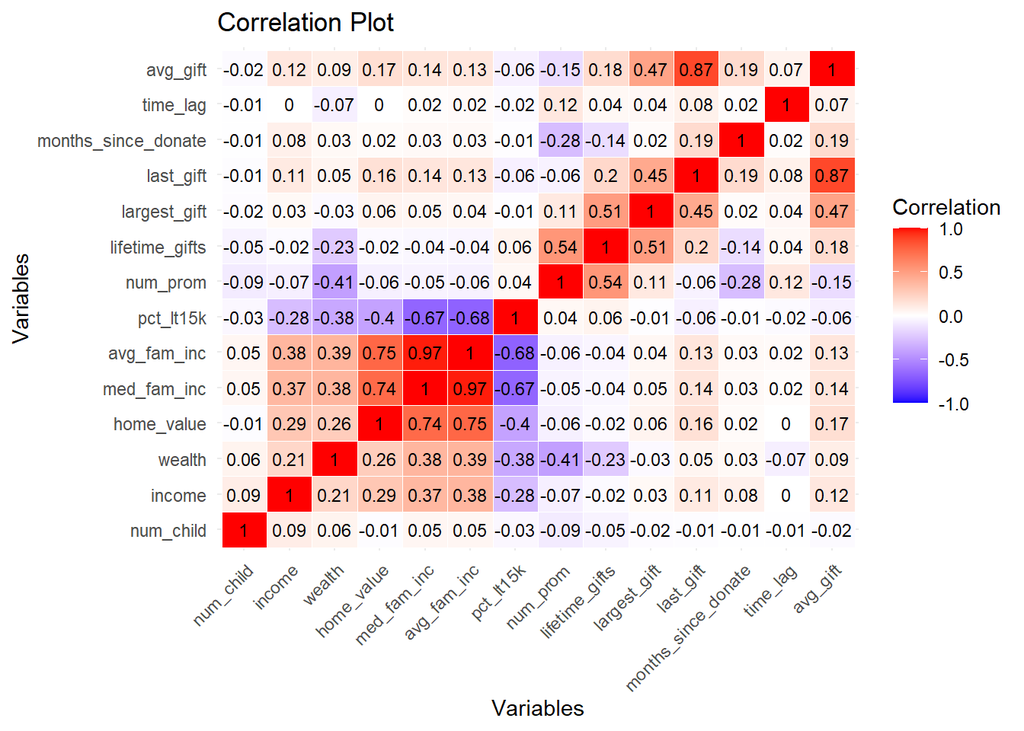

```r
melted_corr <- melt(correlation_matrix)

ggplot(data = melted_corr, aes(x = Var1, y = Var2, fill = value, label = round(value, 2))) +
  geom_tile(color = "white") +
  geom_text(size = 3, color = "black") +
  scale_fill_gradient2(low = "blue", mid = "white", high = "red", midpoint = 0, limits = c(-1, 1), name = "Correlation") +
  theme_minimal() +
  theme(axis.text.x = element_text(angle = 45, hjust = 1),
        axis.text.y = element_text(angle = 0, hjust = 1)) +
  labs(title = "Correlation Plot", x = "Variables", y = "Variables")
```

## Interpretation:

From the above correlation plot the highly correlated variables are avg_fam_inc, med_fam_inc, avg_gift, and last_gift.

## Pairwise plot for high correlated variabels:-

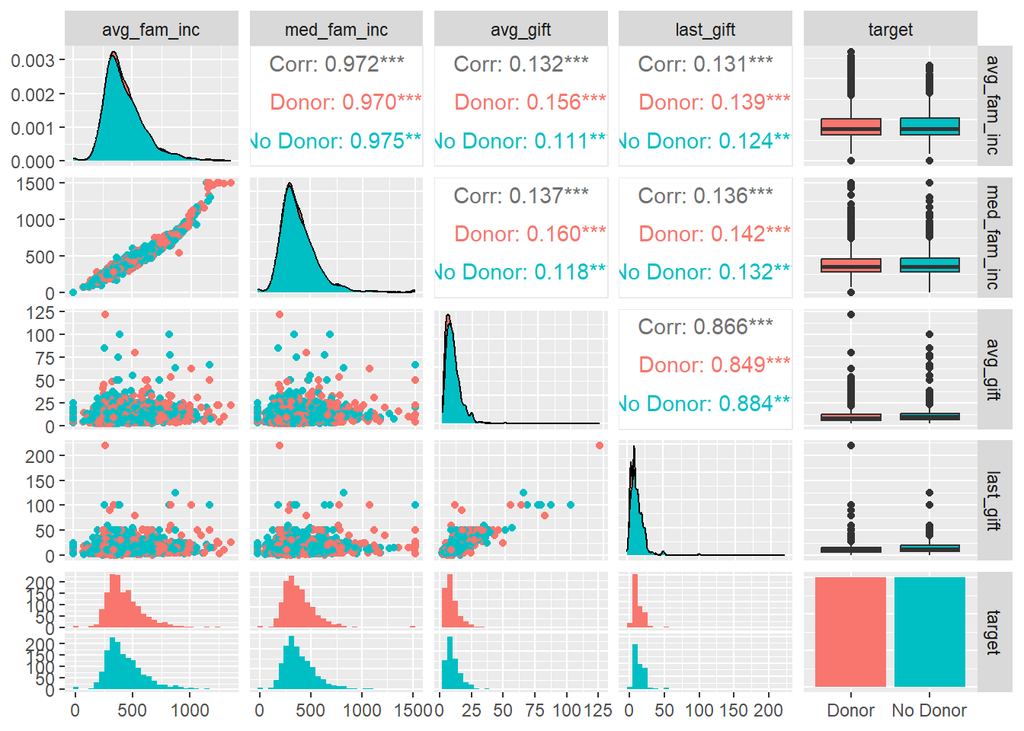

```r
# pairwise plot for the highly correlated variables:

subset_data <- Fundraising_data[, correlated_pairs$Variable1]

subset_data$target <- Fundraising_data$target

ggpairs(subset_data, aes(colour = target))
```

## Interpretation:

The variables avg_gift, and last_gift are positively skewed ot Right skewness (tail to the right), I have noticed that their is high correlation between these variables along with the some correlation with the target variable(response variable).

## Histogram for numeric variables:-

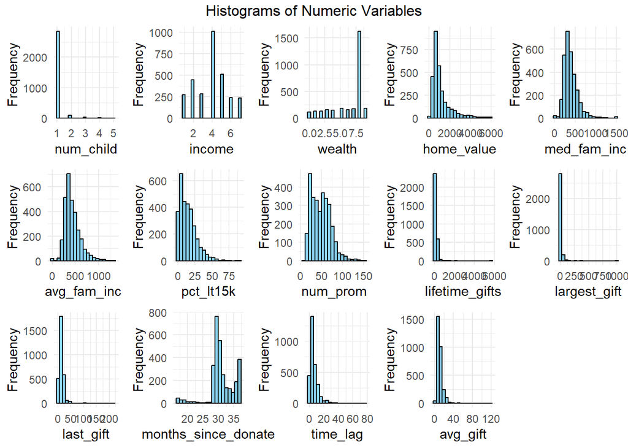

```r
plot_histogram <- function(data, variable) {
  ggplot(data, aes(x = !!as.name(variable))) +
    geom_histogram(fill = "skyblue", color = "black", bins = 20) +
    labs(title =, x = variable, y = "Frequency") +
    theme_minimal()
}

numeric_variables <- c("num_child", "income", "wealth", "home_value", "med_fam_inc",
                       "avg_fam_inc", "pct_lt15k", "num_prom", "lifetime_gifts",
                       "largest_gift", "last_gift", "months_since_donate",
                       "time_lag", "avg_gift")

histogram_plots <- list()

for (variable in numeric_variables) {
  histogram_plots[[variable]] <- plot_histogram(Fundraising_data, variable)
}

combined_plots <- grid.arrange(grobs = histogram_plots, ncol = 5, top = "Histograms of Numeric Variables")
```

```r
print(combined_plots)
```

## categorical variable bar plots:-

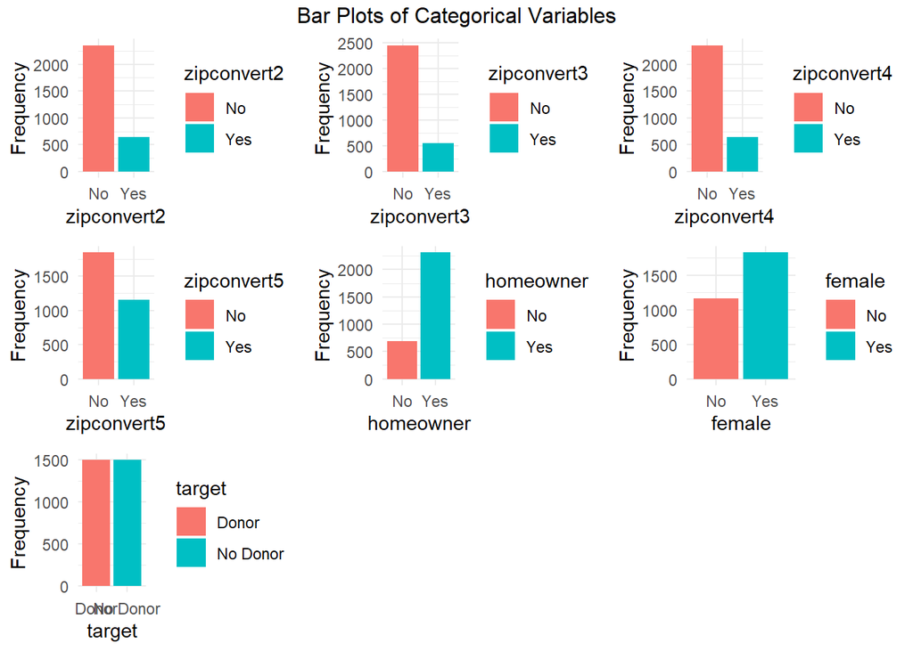

```r
bar_plot_list <- list()

for (col in names(Fundraising_data)) {
  if (is.factor(Fundraising_data[[col]]) || is.character(Fundraising_data[[col]])) {

    plot <- ggplot(Fundraising_data, aes(x = !!sym(col), fill = !!sym(col))) +
      geom_bar() +
      labs(title =, x = col, y = "Frequency") +
      theme_minimal()

    bar_plot_list[[col]] <- plot
  }
}


combined_bar_plots <- do.call(grid.arrange, c(bar_plot_list, ncol = 3, top = "Bar Plots of Categorical Variables"))
```

```r
print(combined_bar_plots)
```

## Predictive Modeling:-

## Step 1: Partitioning. You might think about how to estimate the out of sample error. Either partition the dataset into 80% training and 20% validation or use cross validation (set the seed to 12345).

## Fundraising_data split 80-20 rule:-

```r
set.seed(12345)
data_index_80_20_split = sample(1:nrow(Fundraising_data), round(nrow(Fundraising_data) * 0.80))
train_data_split = Fundraising_data[data_index_80_20_split, ]
test_data_split = Fundraising_data[-data_index_80_20_split, ]
```

## checking multicollinearity:-

```r
### Building model with whole data
set.seed(12345)
m1.log_wholedata = glm(target ~. -zipconvert2, data = train_data_split, family = binomial)
summary(m1.log_wholedata)
```

```
##
## Call:
## glm(formula = target ~ . - zipconvert2, family = binomial, data = train_data_split)
##
## Coefficients:
##                       Estimate Std. Error z value Pr(>|z|)
## (Intercept)         -1.736e+00  5.176e-01  -3.354 0.000797 ***
## zipconvert3Yes       9.853e-02  1.335e-01   0.738 0.460643
## zipconvert4Yes       3.228e-02  1.283e-01   0.252 0.801362
## zipconvert5Yes       6.280e-02  1.213e-01   0.518 0.604576
## homeownerYes        -1.483e-01  1.059e-01  -1.401 0.161240
## num_child            3.324e-01  1.279e-01   2.600 0.009327 **
## income              -5.440e-02  2.876e-02  -1.892 0.058537 .
## femaleYes           -2.616e-02  8.587e-02  -0.305 0.760655
## wealth              -2.034e-02  1.997e-02  -1.018 0.308481
## home_value          -9.720e-05  7.962e-05  -1.221 0.222156
## med_fam_inc         -1.220e-03  1.063e-03  -1.147 0.251266
## avg_fam_inc          1.668e-03  1.136e-03   1.469 0.141852
## pct_lt15k           -3.696e-03  4.940e-03  -0.748 0.454325
## num_prom            -4.062e-03  2.569e-03  -1.581 0.113822
## lifetime_gifts       2.916e-04  4.033e-04   0.723 0.469762
## largest_gift        -2.219e-03  3.406e-03  -0.652 0.514625
## last_gift            1.381e-02  8.668e-03   1.593 0.111200
## months_since_donate  5.363e-02  1.126e-02   4.762 1.91e-06 ***
## time_lag            -1.160e-03  7.743e-03  -0.150 0.880878
## avg_gift             5.650e-03  1.237e-02   0.457 0.647882
## ---
## Signif. codes:  0 '***' 0.001 '**' 0.01 '*' 0.05 '.' 0.1 ' ' 1
##
## (Dispersion parameter for binomial family taken to be 1)
##
##     Null deviance: 3327.0  on 2399  degrees of freedom
## Residual deviance: 3253.1  on 2380  degrees of freedom
## AIC: 3293.1
##
## Number of Fisher Scoring iterations: 4
```

```r
vif_wholedata_log_reg<-vif(m1.log_wholedata)
```

```r
print( vif_wholedata_log_reg)
```

```
##         zipconvert3         zipconvert4         zipconvert5           homeowner
##            1.583803            1.613826            2.030926            1.149109
##           num_child              income              female              wealth
##            1.026845            1.318902            1.017133            1.540787
##          home_value         med_fam_inc         avg_fam_inc           pct_lt15k
##            3.292901           19.255141           21.116940            2.069671
##            num_prom      lifetime_gifts        largest_gift           last_gift
##            1.943870            2.096937            1.990150            3.550115
## months_since_donate            time_lag            avg_gift
##            1.153031            1.045598            3.853753
```

## Interpretation:

I have removed “zipconvert2” as the VIF co-efficients are getting influenced by this variable due to high correlation.

VIF co-efficient values below 5 indicate low multicollinearity and are generally acceptable for any data analysis and conversely, VIF co-efficient values above 5 indicate moderate to high multicollinearity, suggesting that the variable would be removed from further analysis. From the above the analysis variables “med_fam_inc”, and “avg_fam_inc” have high VIF co-efficient and even from the exploratory data analysis also suggest that this variables are highly correlated(multicollinearity).

## Using step wise backward elimintaion method for addressing multicollinearity and further modeling:

```r
m2.log_wholedata_stepwise_backward <- step(glm(target ~ . - zipconvert2 - zipconvert3 - zipconvert4 - zipconvert5 -time_lag, data = train_data_split, family = binomial), direction = "backward")
```

```
## Start:  AIC=3285.7
## target ~ (zipconvert2 + zipconvert3 + zipconvert4 + zipconvert5 +
##     homeowner + num_child + income + female + wealth + home_value +
##     med_fam_inc + avg_fam_inc + pct_lt15k + num_prom + lifetime_gifts +
##     largest_gift + last_gift + months_since_donate + time_lag +
##     avg_gift) - zipconvert2 - zipconvert3 - zipconvert4 - zipconvert5 -
##     time_lag
##
##                       Df Deviance    AIC
## - female               1   3253.8 3283.8
## - avg_gift             1   3253.9 3283.9
## - lifetime_gifts       1   3254.3 3284.3
## - largest_gift         1   3254.3 3284.3
## - pct_lt15k            1   3254.4 3284.4
## - wealth               1   3254.9 3284.9
## - med_fam_inc          1   3255.0 3285.0
## - home_value           1   3255.5 3285.5
## <none>                     3253.7 3285.7
## - avg_fam_inc          1   3255.7 3285.7
## - homeowner            1   3255.8 3285.8
## - last_gift            1   3256.3 3286.3
## - num_prom             1   3256.3 3286.3
## - income               1   3257.3 3287.3
## - num_child            1   3260.7 3290.7
## - months_since_donate  1   3276.9 3306.9
##
## Step:  AIC=3283.79
## target ~ homeowner + num_child + income + wealth + home_value +
##     med_fam_inc + avg_fam_inc + pct_lt15k + num_prom + lifetime_gifts +
##     largest_gift + last_gift + months_since_donate + avg_gift
##
##                       Df Deviance    AIC
## - avg_gift             1   3254.0 3282.0
## - lifetime_gifts       1   3254.3 3282.3
## - largest_gift         1   3254.4 3282.4
## - pct_lt15k            1   3254.5 3282.5
## - wealth               1   3255.0 3283.0
## - med_fam_inc          1   3255.0 3283.0
## - home_value           1   3255.6 3283.6
## <none>                     3253.8 3283.8
```

[output cut: 138 more lines]

```
## - income               1   3263.9 3275.9
## - num_child            1   3269.2 3281.2
## - last_gift            1   3273.2 3285.2
## - months_since_donate  1   3291.7 3303.7
##
## Step:  AIC=3273.64
## target ~ homeowner + num_child + income + last_gift + months_since_donate
##
##                       Df Deviance    AIC
## <none>                     3261.6 3273.6
## - homeowner            1   3263.8 3273.8
## - income               1   3265.0 3275.0
## - num_child            1   3269.8 3279.8
## - last_gift            1   3273.2 3283.2
## - months_since_donate  1   3292.4 3302.4
```

```r
vif(m2.log_wholedata_stepwise_backward)
```

```
##           homeowner           num_child              income           last_gift
##            1.132511            1.009586            1.154725            1.063439
## months_since_donate
##            1.056160
```

## Interpretation:

Removed the variables which has the least significant using Backward elimination of AIC value. Post stepwise selection we are left with 5 features(homeowner + num_child + income + last_gift + months_since_donate) we can use this for further prediction of the target(response variable).

Multicollinearity is satisfied here, as VIF for the left over features(homeowner + num_child + income + last_gift + months_since_donate) post step wise(backward) selection has values less than 5(default value for VIF).

## Predict the responses on the testing data:

```r
predprob.m2.log_wholedata_stepwise_backward <- predict.glm(m2.log_wholedata_stepwise_backward, test_data_split, type = "response")
```

```r
## prediction criteria is 0.5 since we have balanced data-frame here:
predclass.predprob.m2.log_wholedata_stepwise_backward = ifelse(predprob.m2.log_wholedata_stepwise_backward >= 0.5, "Donor", "No Donor")
```

## Confustion Matrix:

```r
conf_matrix_log_reg <- confusionMatrix(as.factor(predclass.predprob.m2.log_wholedata_stepwise_backward), test_data_split$target, positive = 'Donor')

conf_matrix_log_reg
```

```
## Confusion Matrix and Statistics
##
##           Reference
## Prediction Donor No Donor
##   Donor      117      145
##   No Donor   173      165
##
##                Accuracy : 0.47
##                  95% CI : (0.4295, 0.5108)
##     No Information Rate : 0.5167
##     P-Value [Acc > NIR] : 0.99
##
##                   Kappa : -0.0645
##
##  Mcnemar's Test P-Value : 0.13
##
##             Sensitivity : 0.4034
##             Specificity : 0.5323
##          Pos Pred Value : 0.4466
##          Neg Pred Value : 0.4882
##              Prevalence : 0.4833
##          Detection Rate : 0.1950
##    Detection Prevalence : 0.4367
##       Balanced Accuracy : 0.4679
##
##        'Positive' Class : Donor
##
```

```r
accuracy_log_reg <- round(conf_matrix_log_reg$overall['Accuracy'], 4)


precision_log_reg <- round(conf_matrix_log_reg$byClass['Precision'], 4)


recall_log_reg <- round(conf_matrix_log_reg$byClass['Sensitivity'], 4)


f1_score_log_reg <- round((2 * precision_log_reg * recall_log_reg) / (precision_log_reg + recall_log_reg), 4)


cat("Accuracy (log_reg):", accuracy_log_reg, "\n")
```

```
## Accuracy (log_reg): 0.47
```

```r
cat("Precision (log_reg):", precision_log_reg, "\n")
```

```
## Precision (log_reg): 0.4466
```

```r
cat("Recall (log_reg):", recall_log_reg, "\n")
```

```
## Recall (log_reg): 0.4034
```

```r
cat("F1 Score (log_reg):", f1_score_log_reg, "\n")
```

```
## F1 Score (log_reg): 0.4239
```

## Interpretation:

From the summary:

Recall: 0.4034 suggests that the model correctly identifies about 40.34% of all actual positive samples Precision: 0.4466 that about 44.66% of the samples predicted as positive are actually positive. F1 Score:0.4239 model has a average balance between precision and recall.

The model’s overall accuracy is 47%, indicating that it correctly classifies 47% of all instances, hence model is not best model for the case study and we will check other models like “Random Forest”, “K-Nearest Neighbor”, “Naive Bayes”.

## ROC and AUC Curve:

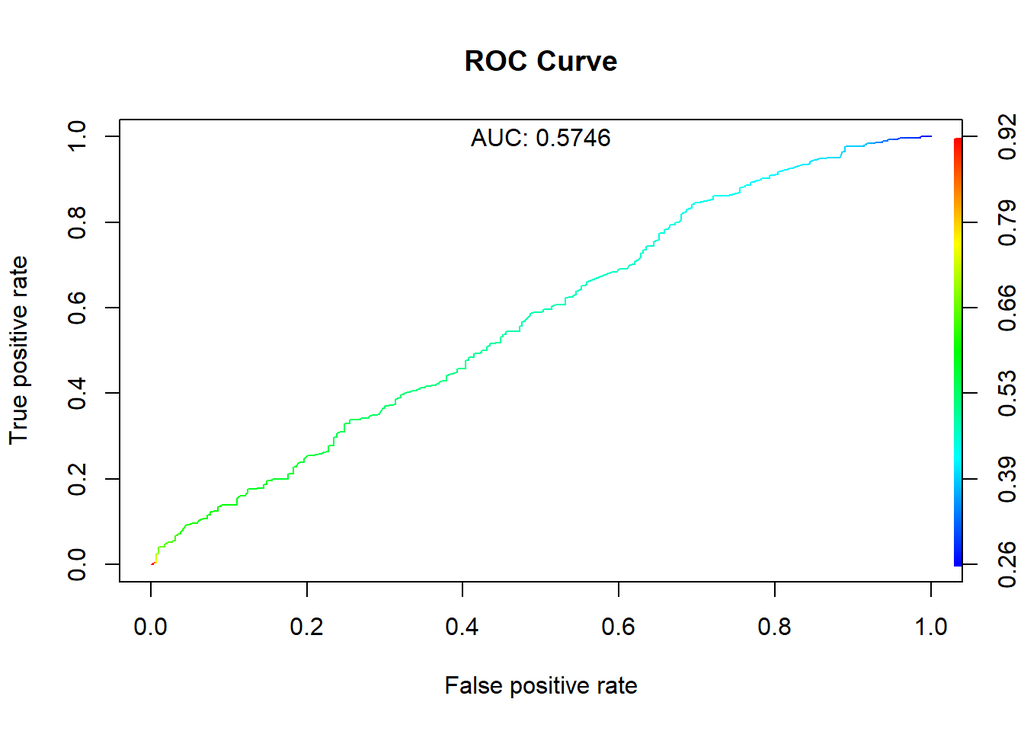

```r
values_pred <- prediction(predict(m2.log_wholedata_stepwise_backward, test_data_split, type = "response"),
test_data_split$target)

auc <- round(as.numeric(performance(values_pred, measure = "auc")@y.values),4)
false_rates <-performance(values_pred, "fpr","fnr")
accuracy_rate <-performance(values_pred, "acc","err")
perform_rate <- performance(values_pred, "tpr","fpr")
plot(perform_rate,colorize = T, main = "ROC Curve")
text(0.5,1, paste("AUC:", auc))
```

## Using Random Forest with variable importance:-

## Full Model:-

```r
set.seed(12345)

formula_rf <- as.formula(paste("target ~ ."))

rf_full = randomForest(formula_rf, data = train_data_split, mtry = 20, ntree = 1000,
    importance = T)
```

```r
pred_rf_tuned <- predict(rf_full, newdata = test_data_split)

# Calculate confusion matrix
conf_matrix_rf_tuned <- confusionMatrix(pred_rf_tuned, test_data_split$target)
conf_matrix_rf_tuned
```

```
## Confusion Matrix and Statistics
##
##           Reference
## Prediction Donor No Donor
##   Donor      175      134
##   No Donor   115      176
##
##                Accuracy : 0.585
##                  95% CI : (0.5444, 0.6248)
##     No Information Rate : 0.5167
##     P-Value [Acc > NIR] : 0.0004536
##
##                   Kappa : 0.1708
##
##  Mcnemar's Test P-Value : 0.2539933
##
##             Sensitivity : 0.6034
##             Specificity : 0.5677
##          Pos Pred Value : 0.5663
##          Neg Pred Value : 0.6048
##              Prevalence : 0.4833
##          Detection Rate : 0.2917
##    Detection Prevalence : 0.5150
##       Balanced Accuracy : 0.5856
##
##        'Positive' Class : Donor
##
```

```r
accuracy_rf_tuned <- conf_matrix_rf_tuned$overall['Accuracy']


precision_rf_tuned <- round(conf_matrix_rf_tuned$byClass['Precision'], 4)


recall_rf_tuned <- round(conf_matrix_rf_tuned$byClass['Sensitivity'], 4)

f1_score_rf_tuned <- round((2 * precision_rf_tuned * recall_rf_tuned) / (precision_rf_tuned + recall_rf_tuned), 4)

cat("Accuracy (_rf_tuned):", round(accuracy_rf_tuned,4), "\n")
```

```
## Accuracy (_rf_tuned): 0.585
```

```r
cat("Precision (_rf_tuned):", precision_rf_tuned, "\n")
```

```
## Precision (_rf_tuned): 0.5663
```

```r
cat("Recall (_rf_tuned):", recall_rf_tuned, "\n")
```

```
## Recall (_rf_tuned): 0.6034
```

```r
cat("F1 Score (_rf_tuned):", f1_score_rf_tuned, "\n")
```

```
## F1 Score (_rf_tuned): 0.5843
```

## Interpretation:

From the confusion matrix:

True Positives (TP): 175, meaning 175 instances were correctly predicted as “Donor.” True Negatives (TN): 176, indicating 176 instances were correctly predicted as “No Donor.” False Positives (FP): 134, representing instances wrongly predicted as “Donor” when they were actually “No Donor.” False Negatives (FN): 115, indicating instances wrongly predicted as “No Donor” when they were actually “Donor.”

From the summary:

Recall: 0.6034 suggests that the model correctly identifies about 60.34% of all actual positive samples Precision: 0.5663 that about 56.63% of the samples predicted as positive are actually positive. F1 Score:0.5843 model has a average balance between precision and recall.

The model’s overall accuracy is 0.585, indicating that it correctly classifies 58.5% of all instances.

## Variable importance graph:-

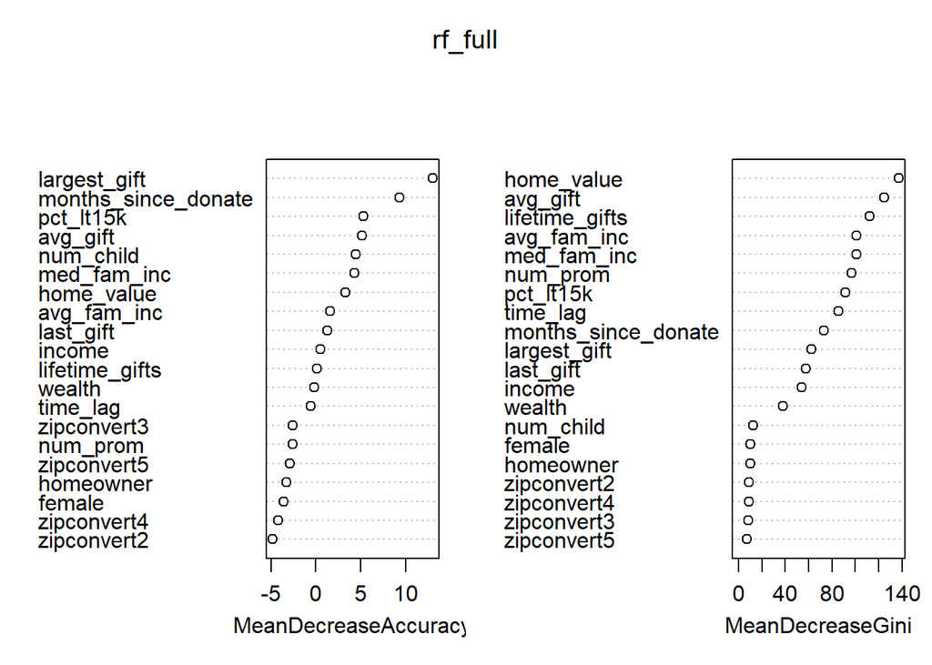

```r
varImpPlot(rf_full)
```

## KNN modeling:

```r
set.seed(12345)

formula_knn <- as.formula(paste("target ~ homeowner + num_child + income + last_gift + months_since_donate"))

ctrl_knn <- trainControl(method = "repeatedcv", number = 3,repeats = 3)

# Train model
knn_modeling <- train(formula_knn,
                 data = train_data_split,
                 method = "knn",
                 trControl = ctrl_knn,
                 tuneLength=195)
```

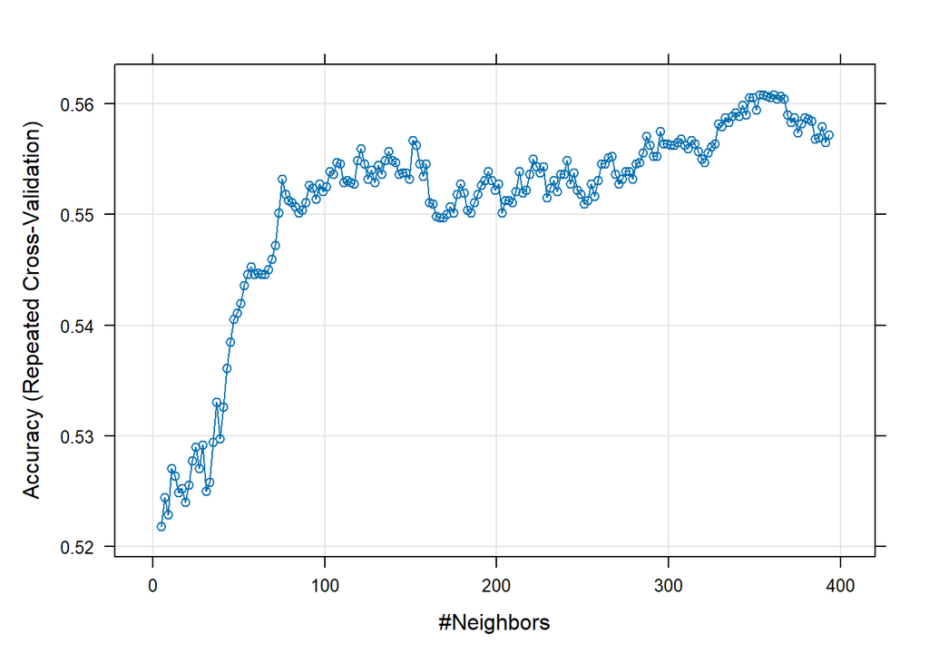

```r
plot(knn_modeling)
```

```r
pred_knn_modeling= predict(knn_modeling, test_data_split)

confusionMatrix(as.factor(pred_knn_modeling), test_data_split$target, positive = 'Donor')
```

```
## Confusion Matrix and Statistics
##
##           Reference
## Prediction Donor No Donor
##   Donor      201      180
##   No Donor    89      130
##
##                Accuracy : 0.5517
##                  95% CI : (0.5109, 0.592)
##     No Information Rate : 0.5167
##     P-Value [Acc > NIR] : 0.04687
##
##                   Kappa : 0.1113
##
##  Mcnemar's Test P-Value : 4.079e-08
##
##             Sensitivity : 0.6931
##             Specificity : 0.4194
##          Pos Pred Value : 0.5276
##          Neg Pred Value : 0.5936
##              Prevalence : 0.4833
##          Detection Rate : 0.3350
##    Detection Prevalence : 0.6350
##       Balanced Accuracy : 0.5562
##
##        'Positive' Class : Donor
##
```

```r
# Calculate confusion matrix
conf_matrix_knn_modeling <- confusionMatrix(as.factor(pred_knn_modeling), test_data_split$target, positive = 'Donor')

# Calculate accuracy
accuracy_knn_modeling <- round(conf_matrix_knn_modeling$overall['Accuracy'], 4)

# Calculate precision
precision_knn_modeling <- round(conf_matrix_knn_modeling$byClass['Precision'], 4)

# Calculate recall (Sensitivity)
recall_knn_modeling <- round(conf_matrix_knn_modeling$byClass['Sensitivity'], 4)

# Calculate F1 score
f1_score_knn_modeling <- round((2 * precision_knn_modeling * recall_knn_modeling) / (precision_knn_modeling + recall_knn_modeling), 4)

# Print the results
cat("Accuracy_knn_modeling:", accuracy_knn_modeling, "\n")
```

```
## Accuracy_knn_modeling: 0.5517
```

```r
cat("Precision_knn_modeling:", precision_knn_modeling, "\n")
```

```
## Precision_knn_modeling: 0.5276
```

```r
cat("Recall_knn_modeling:", recall_knn_modeling, "\n")
```

```
## Recall_knn_modeling: 0.6931
```

```r
cat("F1 Score_knn_modeling:", f1_score_knn_modeling, "\n")
```

```
## F1 Score_knn_modeling: 0.5991
```

## Interpretation:

From the summary:

Recall: 0.6931 suggests that the model correctly identifies about 69.31% of all actual positive samples Precision: 0.5276 that about 52.76% of the samples predicted as positive are actually positive. F1 Score:0.5991 model has a average balance between precision and recall.

The model’s overall accuracy is 55.17%, indicating that it correctly classifies 55.17% of all instances.

## Naive bayes Modeling:

```r
set.seed(12345)
ctrl_nb <- trainControl(method = "repeatedcv", number = 15,repeats = 3)

nb_model_fit = train(target ~ homeowner + num_child + income + last_gift + months_since_donate,
                data = train_data_split, method = "naive_bayes",
                trControl = ctrl_nb)
nb_model_fit
```

```
## Naive Bayes
##
## 2400 samples
##    5 predictor
##    2 classes: 'Donor', 'No Donor'
##
## No pre-processing
## Resampling: Cross-Validated (15 fold, repeated 3 times)
## Summary of sample sizes: 2239, 2240, 2240, 2241, 2240, 2240, ...
## Resampling results across tuning parameters:
##
##   usekernel  Accuracy   Kappa
##   FALSE      0.5410850  0.07849578
##    TRUE      0.5274866  0.05016914
##
## Tuning parameter 'laplace' was held constant at a value of 0
## Tuning
##  parameter 'adjust' was held constant at a value of 1
## Accuracy was used to select the optimal model using the largest value.
## The final values used for the model were laplace = 0, usekernel = FALSE
##  and adjust = 1.
```

```r
pred_nb_model_fit= predict(nb_model_fit, test_data_split)

conf_matrix_nb_model_fit<-confusionMatrix(as.factor(pred_nb_model_fit), test_data_split$target, positive = 'Donor')
conf_matrix_nb_model_fit
```

```
## Confusion Matrix and Statistics
##
##           Reference
## Prediction Donor No Donor
##   Donor      231      234
##   No Donor    59       76
##
##                Accuracy : 0.5117
##                  95% CI : (0.4709, 0.5524)
##     No Information Rate : 0.5167
##     P-Value [Acc > NIR] : 0.6127
##
##                   Kappa : 0.0409
##
##  Mcnemar's Test P-Value : <2e-16
##
##             Sensitivity : 0.7966
##             Specificity : 0.2452
##          Pos Pred Value : 0.4968
##          Neg Pred Value : 0.5630
##              Prevalence : 0.4833
##          Detection Rate : 0.3850
##    Detection Prevalence : 0.7750
##       Balanced Accuracy : 0.5209
##
##        'Positive' Class : Donor
##
```

```r
# Calculate accuracy
accuracy_nb_model_fit <- round(conf_matrix_nb_model_fit$overall['Accuracy'], 4)

# Calculate precision
precision_nb_model_fit <- round(conf_matrix_nb_model_fit$byClass['Precision'], 4)

# Calculate recall (Sensitivity)
recall_nb_model_fit <- round(conf_matrix_nb_model_fit$byClass['Sensitivity'], 4)

# Calculate F1 score
f1_score_nb_model_fit <- round((2 * precision_nb_model_fit * recall_nb_model_fit) / (precision_nb_model_fit + recall_nb_model_fit), 4)

# Print the results
cat("Accuracy_nb_model_fit:", accuracy_nb_model_fit, "\n")
```

```
## Accuracy_nb_model_fit: 0.5117
```

```r
cat("Precision_nb_model_fit:", precision_nb_model_fit, "\n")
```

```
## Precision_nb_model_fit: 0.4968
```

```r
cat("Recall_nb_model_fit:", recall_nb_model_fit, "\n")
```

```
## Recall_nb_model_fit: 0.7966
```

```r
cat("F1 Score_nb_model_fit:", f1_score_nb_model_fit, "\n")
```

```
## F1 Score_nb_model_fit: 0.612
```

## Interpretation:

From the summary:

Recall: 0.7966 suggests that the model correctly identifies about 79.66% of all actual positive samples Precision: 0.4968 that about 49.68% of the samples predicted as positive are actually positive. F1 Score:0.612 model has a average balance between precision and recall.

The model’s overall accuracy is 0.5117, indicating that it correctly classifies 51.17% of all instances.

## Model Comparision to find the best accuracy:

```r
Model_accu_all = data.frame(accuracy_log_reg ,accuracy_rf_tuned,accuracy_knn_modeling,accuracy_nb_model_fit)
colnames(Model_accu_all) <- c("Logistic Regression Model","Random Forest Model","K-Nearest Neighbor Model","Naive Bayes Model")

Model_accu_all
```

```
##          Logistic Regression Model Random Forest Model K-Nearest Neighbor Model
## Accuracy                      0.47               0.585                   0.5517
##          Naive Bayes Model
## Accuracy            0.5117
```

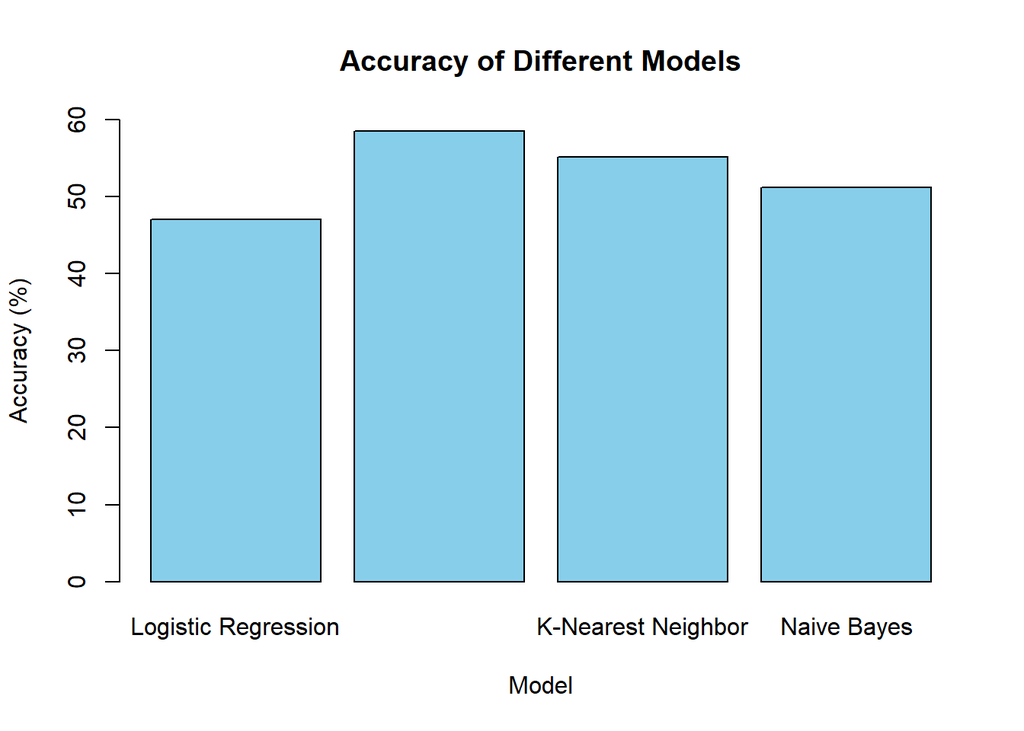

```r
Model_accu_all <- data.frame(
  Accuracy = c(accuracy_log_reg ,accuracy_rf_tuned,accuracy_knn_modeling,accuracy_nb_model_fit),
  Model = c("Logistic Regression", "Random Forest", "K-Nearest Neighbor", "Naive Bayes")
)


Model_accu_all$Accuracy <- Model_accu_all$Accuracy * 100


barplot(Model_accu_all$Accuracy, names.arg = Model_accu_all$Model,
        ylim = c(0, 60), col = "skyblue",
        main = "Accuracy of Different Models",
        xlab = "Model", ylab = "Accuracy (%)")
```

## Testing on Future_fundraising test file:-

```r
set.seed(12345)

formula_rf <- as.formula(paste("target ~ homeowner + num_child + income + last_gift + months_since_donate"))

rf_full_future_fund = randomForest(formula_rf, data = train_data_split, mtry = 5, ntree = 1000,
    importance = T)
```

```r
pred_probs_rf_full_modeling_Future_fundraising = predict(rf_full_future_fund, Future_fundraising)
```

```r
# Write header to CSV file
header <- "value"
write(header, file = "predictions_rf_full_Future_fundraising_final.csv")

# Append data to CSV file
write.table(pred_probs_rf_full_modeling_Future_fundraising, file = "predictions_rf_full_Future_fundraising_final.csv", col.names = FALSE, row.names = FALSE, append = TRUE, sep = ",")
```

## What percentage of your data would you recommend for a mailing campaign?

## Cut-off analysis:

```r
pred_probs_rf_full_modeling_Future_fundraising <- predict(rf_full_future_fund, Future_fundraising, type = "prob")[, "Donor"]


mailing_cost <- 0.68
average_donation_value <- 13
donor_response_rate <- 0.051
```

```r
cutoff_values <- seq(0, 0.8, by = 0.01)

calculate_targeted_counts <- function(cutoff) {
  sum(pred_probs_rf_full_modeling_Future_fundraising > cutoff)
}

targeted_counts <- sapply(cutoff_values, calculate_targeted_counts)
expected_donors <- targeted_counts * donor_response_rate
total_costs <- targeted_counts * mailing_cost
total_benefits <- expected_donors * average_donation_value
net_benefits <- total_benefits - total_costs

cutoff_analysis_df <- data.frame(
  cutoff = cutoff_values,
  total_cost = total_costs,
  total_benefit = total_benefits,
  net = net_benefits
)


optimal_cutoff <- cutoff_analysis_df[cutoff_analysis_df$net == max(cutoff_analysis_df$net), "cutoff"]
optimal_cutoff <- optimal_cutoff[1]
cat("Optimal Cutoff: ", optimal_cutoff,"\n")
```

```
## Optimal Cutoff:  0.79
```

## Recommendation:

```r
probability_threshold <-optimal_cutoff

num_targeted <- sum(pred_probs_rf_full_modeling_Future_fundraising > probability_threshold)

percentage_to_use <- (num_targeted / length(pred_probs_rf_full_modeling_Future_fundraising)) * 100

cat("Percentage of data to use for the mailing campaign: ", percentage_to_use, "%\n")
```

```
## Percentage of data to use for the mailing campaign:  20 %
```

```r
total_costs <- num_targeted * mailing_cost
expected_donors <- num_targeted * donor_response_rate
total_benefits <- expected_donors * average_donation_value
net_benefits <- total_benefits - total_costs

cat("Total Costs: $", total_costs, "\n")
```

```
## Total Costs: $ 16.32
```

```r
cat("Expected Donors: ", expected_donors, "\n")
```

```
## Expected Donors:  1.224
```

```r
cat("Total Benefits: $", total_benefits, "\n")
```

```
## Total Benefits: $ 15.912
```

```r
cat("Net Benefits: $", net_benefits, "\n")
```

```
## Net Benefits: $ -0.408
```